# Phan tich Forest plot stress vs non-stress ratio

Minh

2024-02-28

## Load bộ số liệu và các packages

## So sánh khác biệt về ratio của chỉ số Stress vs non stress theo các biến

Hàm để tạo bảng tổng hợp kết quả và p-value

Hàm sắp xếp các cột theo thứ tự

Hàm vẽ Forest plot

Bảng Stress index Ratio, level1 = “Yes”, level2 = “No”

|  | Variable | Subgroup | Level1_Mean | Level2_Mean | Ratio | CI_Lower | CI_Upper | P_Value |
| --- | --- | --- | --- | --- | --- | --- | --- | --- |
| M_right | M_right | Stress index | 26.6150000 | 20.8004737 | 1.2795382 | 1.0520922 | 1.524981 | 0.0124304 |
| Kv100_right | Kv100_right | Stress index | 20.0149537 | 20.5717076 | 0.9729359 | 0.6996103 | 1.276161 | 0.9258715 |
| δ_right | δ_right | Stress index | 4.4667130 | 3.5209006 | 1.2686280 | 1.0164778 | 1.546612 | 0.0365822 |
| T_right | T_right | Stress index | 33.0212500 | 30.6937485 | 1.0758298 | 1.0294515 | 1.123978 | 0.0645423 |
| A365_right | A365_right | Stress index | 80.3287037 | 84.7959064 | 0.9473182 | 0.7306616 | 1.168785 | 0.6022815 |
| A460_right | A460_right | Stress index | 47.3703704 | 50.8029240 | 0.9324339 | 0.7034033 | 1.165496 | 0.7376304 |
| Anadn_right | Anadn_right | Stress index | 0.8876852 | 0.7966140 | 1.1143228 | 0.6768575 | 1.847355 | 0.8816304 |
| POM_right | POM_right | Stress index | 11.0158796 | 8.8342222 | 1.2469552 | 0.8269187 | 1.756948 | 0.2079775 |
| A-E_right | A-E_right | Stress index | 1.5577778 | 1.3136316 | 1.1858559 | 0.8984505 | 1.511861 | 0.1449190 |
| A-N_right | A-N_right | Stress index | 1.4760185 | 1.2948830 | 1.1398856 | 0.8638775 | 1.502180 | 0.2916255 |
| A-M_right | A-M_right | Stress index | 1.2175463 | 1.0297661 | 1.1823523 | 0.8676557 | 1.580976 | 0.3031312 |
| A-R_right | A-R_right | Stress index | 0.7566667 | 0.6569708 | 1.1517509 | 0.9598246 | 1.388256 | 0.1208796 |
| A-C_right | A-C_right | Stress index | 0.9864815 | 0.8660702 | 1.1390318 | 0.9560478 | 1.382744 | 0.0963868 |
| F-E_right | F-E_right | Stress index | 0.0144074 | 0.0148433 | 0.9706354 | 0.8500165 | 1.093391 | 0.6177072 |
| F-N_right | F-N_right | Stress index | 0.0343981 | 0.0320766 | 1.0723749 | 0.9017986 | 1.270551 | 0.3805532 |
| F-M_right | F-M_right | Stress index | 0.0852407 | 0.0867292 | 0.9828374 | 0.7943090 | 1.220397 | 0.7688536 |
| F-R_right | F-R_right | Stress index | 0.3491713 | 0.3131749 | 1.1149404 | 0.8890461 | 1.341004 | 0.5377722 |
| F-C_right | F-C_right | Stress index | 1.1144722 | 1.1518327 | 0.9675643 | 0.8841262 | 1.049521 | 0.5630896 |

Forest plot cho Stress index ratio

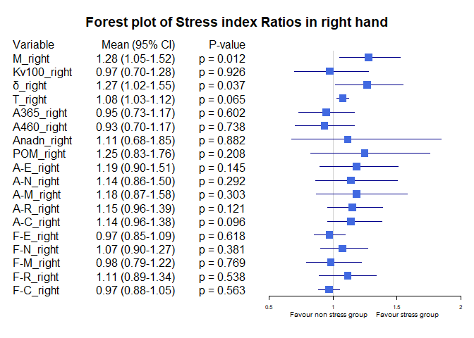

Bảng Gender Ratio, level1 = “male”, level2 = “female”

|  | Variable | Subgroup | Level1_Mean | Level2_Mean | Ratio | CI_Lower | CI_Upper | P_Value |
| --- | --- | --- | --- | --- | --- | --- | --- | --- |
| M_right | M_right | Gender | 22.8633788 | 21.2486559 | 1.0759918 | 0.8973971 | 1.309421 | 0.4006173 |
| Kv100_right | Kv100_right | Gender | 19.2345985 | 22.1462634 | 0.8685257 | 0.6738445 | 1.167024 | 0.2961153 |
| δ_right | δ_right | Gender | 3.7399924 | 3.7591129 | 0.9949136 | 0.7848635 | 1.277225 | 0.8464324 |
| T_right | T_right | Gender | 30.9522424 | 31.6783065 | 0.9770801 | 0.9264373 | 1.030031 | 0.9485282 |
| A365_right | A365_right | Gender | 83.5234848 | 84.0080645 | 0.9942317 | 0.8192488 | 1.203893 | 0.9015111 |
| A460_right | A460_right | Gender | 50.3734848 | 49.4193548 | 1.0193068 | 0.8442492 | 1.213998 | 0.8675353 |
| Anadn_right | Anadn_right | Gender | 0.7017500 | 0.9841398 | 0.7130593 | 0.4733724 | 1.158192 | 0.6984398 |
| POM_right | POM_right | Gender | 9.3750909 | 9.3333065 | 1.0044769 | 0.7401244 | 1.412505 | 0.5243332 |
| A-E_right | A-E_right | Gender | 1.4415606 | 1.2738172 | 1.1316856 | 0.8648556 | 1.473281 | 0.5831796 |
| A-N_right | A-N_right | Gender | 1.4019318 | 1.2481183 | 1.1232363 | 0.8686875 | 1.471387 | 0.5290407 |
| A-M_right | A-M_right | Gender | 1.1082197 | 1.0274462 | 1.0786158 | 0.8159325 | 1.396915 | 0.4448863 |
| A-R_right | A-R_right | Gender | 0.6885758 | 0.6700000 | 1.0277250 | 0.8404420 | 1.271097 | 0.3746122 |
| A-C_right | A-C_right | Gender | 0.9059697 | 0.8793548 | 1.0302663 | 0.8361743 | 1.267882 | 0.7549857 |
| F-E_right | F-E_right | Gender | 0.0148311 | 0.0146075 | 1.0153026 | 0.9076134 | 1.129472 | 0.6888593 |
| F-N_right | F-N_right | Gender | 0.0313795 | 0.0344140 | 0.9118256 | 0.7968821 | 1.053152 | 0.1365770 |
| F-M_right | F-M_right | Gender | 0.0879409 | 0.0841452 | 1.0451095 | 0.8575479 | 1.249291 | 0.8452175 |
| F-R_right | F-R_right | Gender | 0.3167152 | 0.3290511 | 0.9625106 | 0.7932035 | 1.182931 | 0.9565113 |
| F-C_right | F-C_right | Gender | 1.1480523 | 1.1355054 | 1.0110496 | 0.9407062 | 1.098351 | 0.7544507 |

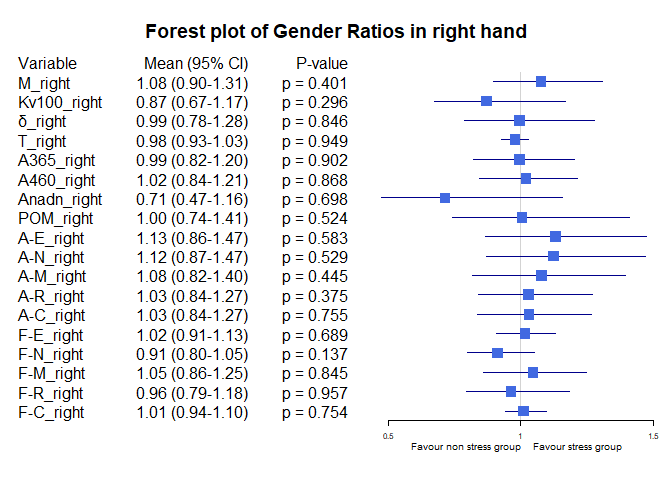

Bảng Smoking ratio, level1 = “Cigarettes, pipe tobacco…”, level2 = “Do not smoke”

|  | Variable | Subgroup | Level1_Mean | Level2_Mean | Ratio | CI_Lower | CI_Upper | P_Value |
| --- | --- | --- | --- | --- | --- | --- | --- | --- |
| M_right | M_right | Smoking | 19.9137692 | 22.6744839 | 0.8782458 | 0.6032870 | 1.1521041 | 0.4796795 |
| Kv100_right | Kv100_right | Smoking | 14.7424615 | 21.6323306 | 0.6815013 | 0.5339371 | 0.8663571 | 0.1474417 |
| δ_right | δ_right | Smoking | 2.6939231 | 3.9688898 | 0.6787599 | 0.4609309 | 0.9501214 | 0.0484299 |
| T_right | T_right | Smoking | 29.7060000 | 31.5765833 | 0.9407604 | 0.8448919 | 1.0317680 | 0.3447796 |
| A365_right | A365_right | Smoking | 83.2692308 | 83.8190860 | 0.9934400 | 0.7015903 | 1.2757859 | 0.9163818 |
| A460_right | A460_right | Smoking | 53.0307692 | 49.3392473 | 1.0748192 | 0.7511043 | 1.4074526 | 0.4623910 |
| Anadn_right | Anadn_right | Smoking | 0.7720769 | 0.8281989 | 0.9322361 | 0.6334068 | 1.3683837 | 0.3591432 |
| POM_right | POM_right | Smoking | 8.1832308 | 9.6041048 | 0.8520555 | 0.4433065 | 1.3538725 | 0.1954352 |
| A-E_right | A-E_right | Smoking | 1.0740769 | 1.4347419 | 0.7486203 | 0.4575358 | 1.0893524 | 0.0957799 |
| A-N_right | A-N_right | Smoking | 1.0848462 | 1.3915108 | 0.7796175 | 0.4708054 | 1.1376242 | 0.1044305 |
| A-M_right | A-M_right | Smoking | 0.8373077 | 1.1246371 | 0.7445137 | 0.4571320 | 1.0937271 | 0.0903183 |
| A-R_right | A-R_right | Smoking | 0.5753846 | 0.7030215 | 0.8184453 | 0.5832434 | 1.1011268 | 0.1744580 |
| A-C_right | A-C_right | Smoking | 0.7739231 | 0.9203495 | 0.8409013 | 0.5412574 | 1.2347655 | 0.1287901 |
| F-E_right | F-E_right | Smoking | 0.0149308 | 0.0146984 | 1.0158100 | 0.8798892 | 1.1449684 | 0.8547887 |
| F-N_right | F-N_right | Smoking | 0.0305923 | 0.0330618 | 0.9253060 | 0.7562519 | 1.1329503 | 0.3653913 |
| F-M_right | F-M_right | Smoking | 0.1059000 | 0.0822774 | 1.2871089 | 0.9286069 | 1.6816158 | 0.2092199 |
| F-R_right | F-R_right | Smoking | 0.2712615 | 0.3324137 | 0.8160360 | 0.6579697 | 1.0150607 | 0.2333425 |
| F-C_right | F-C_right | Smoking | 1.2202615 | 1.1266382 | 1.0830998 | 0.9953443 | 1.1887652 | 0.2676827 |

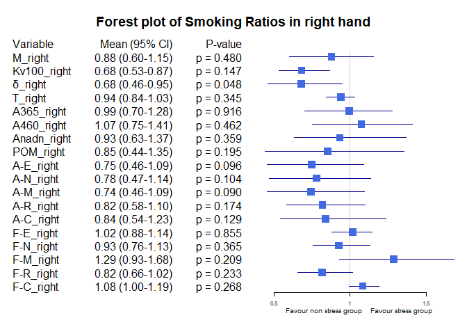

Bảng Smoking ratio, level1 = “Cigarettes, pipe tobacco…”, level2 = “Do not smoke”

|  | Variable | Subgroup | Level1_Mean | Level2_Mean | Ratio | CI_Lower | CI_Upper | P_Value |
| --- | --- | --- | --- | --- | --- | --- | --- | --- |
| M_right | M_right | Smoking | 19.9137692 | 22.6744839 | 0.8782458 | 0.6100179 | 1.1521213 | 0.4796795 |
| Kv100_right | Kv100_right | Smoking | 14.7424615 | 21.6323306 | 0.6815013 | 0.5370132 | 0.8518493 | 0.1474417 |
| δ_right | δ_right | Smoking | 2.6939231 | 3.9688898 | 0.6787599 | 0.4626052 | 0.9183535 | 0.0484299 |
| T_right | T_right | Smoking | 29.7060000 | 31.5765833 | 0.9407604 | 0.8472999 | 1.0309438 | 0.3447796 |
| A365_right | A365_right | Smoking | 83.2692308 | 83.8190860 | 0.9934400 | 0.7209159 | 1.2650304 | 0.9163818 |
| A460_right | A460_right | Smoking | 53.0307692 | 49.3392473 | 1.0748192 | 0.7466011 | 1.4157059 | 0.4623910 |
| Anadn_right | Anadn_right | Smoking | 0.7720769 | 0.8281989 | 0.9322361 | 0.6192203 | 1.3681254 | 0.3591432 |
| POM_right | POM_right | Smoking | 8.1832308 | 9.6041048 | 0.8520555 | 0.4592942 | 1.3960250 | 0.1954352 |
| A-E_right | A-E_right | Smoking | 1.0740769 | 1.4347419 | 0.7486203 | 0.4854284 | 1.1232629 | 0.0957799 |
| A-N_right | A-N_right | Smoking | 1.0848462 | 1.3915108 | 0.7796175 | 0.4650643 | 1.1595997 | 0.1044305 |
| A-M_right | A-M_right | Smoking | 0.8373077 | 1.1246371 | 0.7445137 | 0.4700365 | 1.0698517 | 0.0903183 |
| A-R_right | A-R_right | Smoking | 0.5753846 | 0.7030215 | 0.8184453 | 0.5837077 | 1.0781860 | 0.1744580 |
| A-C_right | A-C_right | Smoking | 0.7739231 | 0.9203495 | 0.8409013 | 0.5441556 | 1.1883129 | 0.1287901 |
| F-E_right | F-E_right | Smoking | 0.0149308 | 0.0146984 | 1.0158100 | 0.8891284 | 1.1429132 | 0.8547887 |
| F-N_right | F-N_right | Smoking | 0.0305923 | 0.0330618 | 0.9253060 | 0.7707584 | 1.1254634 | 0.3653913 |
| F-M_right | F-M_right | Smoking | 0.1059000 | 0.0822774 | 1.2871089 | 0.9307325 | 1.7146823 | 0.2092199 |
| F-R_right | F-R_right | Smoking | 0.2712615 | 0.3324137 | 0.8160360 | 0.6609047 | 1.0246141 | 0.2333425 |
| F-C_right | F-C_right | Smoking | 1.2202615 | 1.1266382 | 1.0830998 | 0.9851828 | 1.1894765 | 0.2676827 |

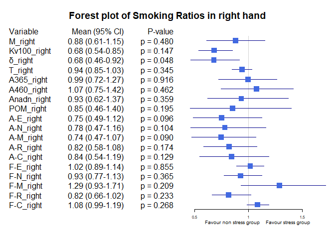

Bảng Hypertension ratio, level1 = “Yes”, level2 = “No”

|  | Variable | Subgroup | Level1_Mean | Level2_Mean | Ratio | CI_Lower | CI_Upper | P_Value |
| --- | --- | --- | --- | --- | --- | --- | --- | --- |
| M_right | M_right | Hypertension | 19.8770476 | 23.0977593 | 0.8605617 | 0.6721204 | 1.0675963 | 0.2597899 |
| Kv100_right | Kv100_right | Hypertension | 17.1661667 | 21.7105000 | 0.7906850 | 0.5675502 | 1.0799548 | 0.0860008 |
| δ_right | δ_right | Hypertension | 2.6535476 | 4.1734753 | 0.6358125 | 0.4862138 | 0.8073669 | 0.0029424 |
| T_right | T_right | Hypertension | 30.1119762 | 31.6958272 | 0.9500297 | 0.8771768 | 1.0173411 | 0.4189196 |
| A365_right | A365_right | Hypertension | 89.5690476 | 81.4506173 | 1.0996730 | 0.8691070 | 1.3257919 | 0.3792641 |
| A460_right | A460_right | Hypertension | 56.5333333 | 47.4302469 | 1.1919258 | 0.9664942 | 1.4450036 | 0.0996986 |
| Anadn_right | Anadn_right | Hypertension | 0.9819048 | 0.7549136 | 1.3006850 | 0.7773801 | 2.3179160 | 0.2402396 |
| POM_right | POM_right | Hypertension | 6.7061667 | 10.3890185 | 0.6455053 | 0.4486818 | 0.8779055 | 0.0362175 |
| A-E_right | A-E_right | Hypertension | 0.9735238 | 1.5272778 | 0.6374242 | 0.4682166 | 0.8520190 | 0.0064121 |
| A-N_right | A-N_right | Hypertension | 0.9965238 | 1.4712901 | 0.6773129 | 0.4970376 | 0.8789516 | 0.0153035 |
| A-M_right | A-M_right | Hypertension | 0.7798810 | 1.1895370 | 0.6556172 | 0.4856974 | 0.8430883 | 0.0197697 |
| A-R_right | A-R_right | Hypertension | 0.5892381 | 0.7165432 | 0.8223344 | 0.6381401 | 1.0103080 | 0.1234873 |
| A-C_right | A-C_right | Hypertension | 0.7802381 | 0.9395864 | 0.8304059 | 0.6139603 | 1.0811768 | 0.0182547 |
| F-E_right | F-E_right | Hypertension | 0.0146095 | 0.0147889 | 0.9878716 | 0.8900876 | 1.1031257 | 0.9102279 |
| F-N_right | F-N_right | Hypertension | 0.0330952 | 0.0324543 | 1.0197483 | 0.8452570 | 1.2246387 | 0.6962268 |
| F-M_right | F-M_right | Hypertension | 0.0974857 | 0.0820500 | 1.1881257 | 0.9361243 | 1.4619303 | 0.3413031 |
| F-R_right | F-R_right | Hypertension | 0.3452214 | 0.3127111 | 1.1039628 | 0.8859201 | 1.3521271 | 0.3891159 |
| F-C_right | F-C_right | Hypertension | 1.1668286 | 1.1335475 | 1.0293601 | 0.9352895 | 1.1241954 | 0.3500637 |

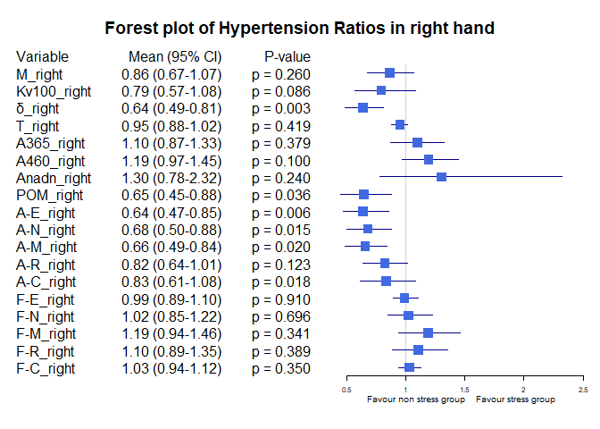

Bảng Obesity ratio, level1 = “Yes”, level2 = “No”

|  | Variable | Subgroup | Level1_Mean | Level2_Mean | Ratio | CI_Lower | CI_Upper | P_Value |
| --- | --- | --- | --- | --- | --- | --- | --- | --- |
| M_right | M_right | Obesity | 27.9056667 | 21.6081961 | 1.2914390 | 1.1329990 | 1.482039 | 0.1069954 |
| Kv100_right | Kv100_right | Obesity | 16.5782619 | 20.8354216 | 0.7956768 | 0.5393319 | 1.079476 | 0.5179169 |
| δ_right | δ_right | Obesity | 4.2837381 | 3.6927353 | 1.1600447 | 0.8623852 | 1.469099 | 0.2949661 |
| T_right | T_right | Obesity | 33.8068810 | 30.9893824 | 1.0909182 | 1.0399604 | 1.145587 | 0.0370332 |
| A365_right | A365_right | Obesity | 95.7547619 | 82.4852941 | 1.1608707 | 0.9386689 | 1.387745 | 0.4281217 |
| A460_right | A460_right | Obesity | 50.1476190 | 49.9617647 | 1.0037199 | 0.8723093 | 1.148848 | 0.9491658 |
| Anadn_right | Anadn_right | Obesity | 0.6214286 | 0.8387549 | 0.7408941 | 0.4682597 | 1.133613 | 0.2783877 |
| POM_right | POM_right | Obesity | 11.1420714 | 9.1741471 | 1.2145076 | 0.8637166 | 1.546658 | 0.1377146 |
| A-E_right | A-E_right | Obesity | 1.7250952 | 1.3359020 | 1.2913337 | 0.8841996 | 1.755595 | 0.1777114 |
| A-N_right | A-N_right | Obesity | 1.6431429 | 1.3069804 | 1.2572054 | 0.8658118 | 1.667485 | 0.1836244 |
| A-M_right | A-M_right | Obesity | 1.0784524 | 1.0744608 | 1.0037150 | 0.7289809 | 1.315654 | 0.6293174 |
| A-R_right | A-R_right | Obesity | 0.6946190 | 0.6794853 | 1.0222724 | 0.8496369 | 1.227118 | 0.6292564 |
| A-C_right | A-C_right | Obesity | 0.9502381 | 0.8892794 | 1.0685484 | 0.8179936 | 1.417904 | 0.5722738 |
| F-E_right | F-E_right | Obesity | 0.0162810 | 0.0145799 | 1.1166709 | 0.9743798 | 1.271431 | 0.2373761 |
| F-N_right | F-N_right | Obesity | 0.0312857 | 0.0327725 | 0.9546317 | 0.7677323 | 1.186937 | 0.8408011 |
| F-M_right | F-M_right | Obesity | 0.0758143 | 0.0874588 | 0.8668569 | 0.6999937 | 1.086204 | 0.6136357 |
| F-R_right | F-R_right | Obesity | 0.3879738 | 0.3150034 | 1.2316495 | 1.0122070 | 1.495269 | 0.0353174 |
| F-C_right | F-C_right | Obesity | 1.1907714 | 1.1379348 | 1.0464320 | 0.9090966 | 1.165513 | 0.4596487 |

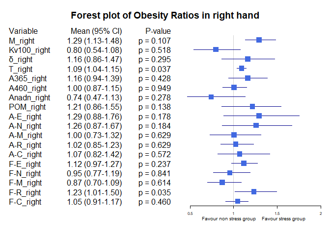

Bảng Race ratio, level1 = “White”, level2 = “Asian or Asian British”

|  | Variable | Subgroup | Level1_Mean | Level2_Mean | Ratio | CI_Lower | CI_Upper | P_Value |
| --- | --- | --- | --- | --- | --- | --- | --- | --- |
| M_right | M_right | Race | 26.1334545 | 21.0673607 | 1.2404712 | 1.0134114 | 1.4798308 | 0.1543522 |
| Kv100_right | Kv100_right | Race | 20.5697273 | 20.5668770 | 1.0001386 | 0.6216682 | 1.4940410 | 0.7661713 |
| δ_right | δ_right | Race | 4.5036667 | 3.5580628 | 1.2657637 | 0.9169344 | 1.6580363 | 0.0909342 |
| T_right | T_right | Race | 32.8315758 | 30.8065383 | 1.0657340 | 1.0142873 | 1.1218225 | 0.1391084 |
| A365_right | A365_right | Race | 103.4878788 | 82.8019126 | 1.2498247 | 1.0706847 | 1.4566773 | 0.0782028 |
| A460_right | A460_right | Race | 47.2606061 | 52.2224044 | 0.9049872 | 0.7585473 | 1.0651027 | 0.4477086 |
| Anadn_right | Anadn_right | Race | 0.4646970 | 0.8431749 | 0.5511276 | 0.4122801 | 0.7158898 | 0.0026480 |
| POM_right | POM_right | Race | 14.9004848 | 8.1369044 | 1.8312228 | 1.3439879 | 2.5422219 | 0.0014081 |
| A-E_right | A-E_right | Race | 1.5626364 | 1.3286557 | 1.1761033 | 0.8130194 | 1.5964331 | 0.2907102 |
| A-N_right | A-N_right | Race | 1.6138182 | 1.2528634 | 1.2881039 | 0.9542027 | 1.6763311 | 0.1086059 |
| A-M_right | A-M_right | Race | 1.2556061 | 1.0159153 | 1.2359358 | 0.9335665 | 1.5562399 | 0.1156763 |
| A-R_right | A-R_right | Race | 0.7183939 | 0.6666393 | 1.0776351 | 0.9203064 | 1.2620452 | 0.2310413 |
| A-C_right | A-C_right | Race | 1.0254545 | 0.8590601 | 1.1936936 | 0.9097561 | 1.5704206 | 0.2132940 |
| F-E_right | F-E_right | Race | 0.0182848 | 0.0142011 | 1.2875663 | 1.1578035 | 1.4120959 | 0.0008005 |
| F-N_right | F-N_right | Race | 0.0289545 | 0.0333284 | 0.8687645 | 0.7404707 | 1.0229006 | 0.4279559 |
| F-M_right | F-M_right | Race | 0.0866697 | 0.0874186 | 0.9914334 | 0.7545053 | 1.3243927 | 0.6308165 |
| F-R_right | F-R_right | Race | 0.3168394 | 0.3183740 | 0.9951797 | 0.7981024 | 1.2233841 | 0.8119590 |
| F-C_right | F-C_right | Race | 1.0897788 | 1.1544656 | 0.9439682 | 0.8624277 | 1.0440294 | 0.1341012 |

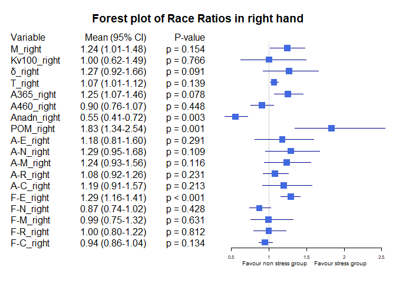

Bảng Race ratio, level1 = “Black, African, Caribbean or Black Bristish”, level2 = “Asian or Asian British”

|  | Variable | Subgroup | Level1_Mean | Level2_Mean | Ratio | CI_Lower | CI_Upper | P_Value |
| --- | --- | --- | --- | --- | --- | --- | --- | --- |
| M_right | M_right | Race | 30.7066667 | 21.0673607 | 1.4575469 | 1.0467745 | 1.8194229 | 0.1122633 |
| Kv100_right | Kv100_right | Race | 17.3366667 | 20.5668770 | 0.8429411 | 0.4809092 | 1.3393461 | 0.8240537 |
| δ_right | δ_right | Race | 4.8366667 | 3.5580628 | 1.3593539 | 1.0047347 | 1.7410357 | 0.1439869 |
| T_right | T_right | Race | 34.5266667 | 30.8065383 | 1.1207578 | 1.0713523 | 1.1736325 | 0.0654461 |
| A365_right | A365_right | Race | 30.0000000 | 82.8019126 | 0.3623105 | 0.0248457 | 0.6703471 | 0.0332960 |
| A460_right | A460_right | Race | 14.3333333 | 52.2224044 | 0.2744671 | 0.1772498 | 0.3782975 | 0.0083724 |
| Anadn_right | Anadn_right | Race | 1.6133333 | 0.8431749 | 1.9134030 | 0.3302826 | 4.2255923 | 0.9873261 |
| POM_right | POM_right | Race | 13.8600000 | 8.1369044 | 1.7033505 | 0.2410090 | 3.3315192 | 0.5461902 |
| A-E_right | A-E_right | Race | 1.5600000 | 1.3286557 | 1.1741190 | 0.8307201 | 1.6109266 | 0.3999214 |
| A-N_right | A-N_right | Race | 2.0666667 | 1.2528634 | 1.6495547 | 0.8913799 | 2.4839408 | 0.1234013 |
| A-M_right | A-M_right | Race | 1.6100000 | 1.0159153 | 1.5847778 | 0.9037463 | 2.4322142 | 0.1273121 |
| A-R_right | A-R_right | Race | 0.8333333 | 0.6666393 | 1.2500512 | 0.8971448 | 1.7021058 | 0.2730167 |
| A-C_right | A-C_right | Race | 1.1466667 | 0.8590601 | 1.3347921 | 1.1444776 | 1.5432730 | 0.0833720 |
| F-E_right | F-E_right | Race | 0.0126667 | 0.0142011 | 0.8919501 | 0.7084820 | 1.1185200 | 0.4149887 |
| F-N_right | F-N_right | Race | 0.0320000 | 0.0333284 | 0.9601417 | 0.8068691 | 1.1144834 | 0.8985214 |
| F-M_right | F-M_right | Race | 0.0640000 | 0.0874186 | 0.7321098 | 0.6475863 | 0.8388188 | 0.1060262 |
| F-R_right | F-R_right | Race | 0.4100000 | 0.3183740 | 1.2877934 | 0.6666494 | 1.8299478 | 0.5294299 |
| F-C_right | F-C_right | Race | 1.1016667 | 1.1544656 | 0.9542655 | 0.8770140 | 1.0350788 | 0.3984758 |

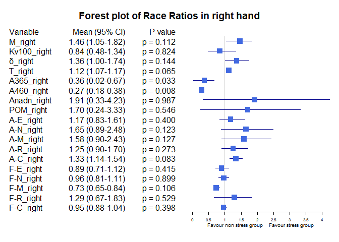

Bảng BMI ratio, level1 = “BMI <25”, level2 = “BMI [25-30)”

|  | Variable | Subgroup | Level1_Mean | Level2_Mean | Ratio | CI_Lower | CI_Upper | P_Value |
| --- | --- | --- | --- | --- | --- | --- | --- | --- |
| M_right | M_right | BMI_25_30 | 18.8375159 | 26.0839103 | 0.7221891 | 0.5872403 | 0.8693166 | 0.0004537 |
| Kv100_right | Kv100_right | BMI_25_30 | 24.0693730 | 15.6113462 | 1.5417872 | 1.1508796 | 2.0872508 | 0.0006167 |
| δ_right | δ_right | BMI_25_30 | 3.8870873 | 3.3787821 | 1.1504404 | 0.9003982 | 1.4534404 | 0.5615457 |
| T_right | T_right | BMI_25_30 | 30.2825317 | 32.1312179 | 0.9424645 | 0.8911403 | 0.9990299 | 0.0151260 |
| A365_right | A365_right | BMI_25_30 | 84.0992063 | 79.8782051 | 1.0528430 | 0.8559081 | 1.3154163 | 0.4994945 |
| A460_right | A460_right | BMI_25_30 | 51.1126984 | 48.1025641 | 1.0625774 | 0.8646047 | 1.2836012 | 0.4796697 |
| Anadn_right | Anadn_right | BMI_25_30 | 0.8071905 | 0.8897436 | 0.9072170 | 0.5120875 | 1.5350591 | 0.9697910 |
| POM_right | POM_right | BMI_25_30 | 7.9520317 | 11.1483333 | 0.7132933 | 0.5187606 | 0.9779828 | 0.0571527 |
| A-E_right | A-E_right | BMI_25_30 | 1.4222937 | 1.1963462 | 1.1888646 | 0.8725794 | 1.6094284 | 0.4565003 |
| A-N_right | A-N_right | BMI_25_30 | 1.3422540 | 1.2500000 | 1.0738032 | 0.8242562 | 1.4383840 | 0.7715921 |
| A-M_right | A-M_right | BMI_25_30 | 1.0641667 | 1.0910897 | 0.9753246 | 0.7477575 | 1.3016990 | 0.7861136 |
| A-R_right | A-R_right | BMI_25_30 | 0.6288095 | 0.7613462 | 0.8259180 | 0.6694209 | 1.0234929 | 0.1250688 |
| A-C_right | A-C_right | BMI_25_30 | 0.8603016 | 0.9360897 | 0.9190375 | 0.7447608 | 1.1626555 | 0.4835716 |
| F-E_right | F-E_right | BMI_25_30 | 0.0143635 | 0.0149295 | 0.9620888 | 0.8589760 | 1.0888176 | 0.7603795 |
| F-N_right | F-N_right | BMI_25_30 | 0.0324294 | 0.0333269 | 0.9730681 | 0.8228944 | 1.1393034 | 0.6578369 |
| F-M_right | F-M_right | BMI_25_30 | 0.0873738 | 0.0875962 | 0.9974617 | 0.8042017 | 1.2397151 | 0.9644584 |
| F-R_right | F-R_right | BMI_25_30 | 0.3054897 | 0.3303718 | 0.9246845 | 0.7501796 | 1.1488560 | 0.1836560 |
| F-C_right | F-C_right | BMI_25_30 | 1.1452714 | 1.1260833 | 1.0170397 | 0.9417707 | 1.0893987 | 0.5604585 |

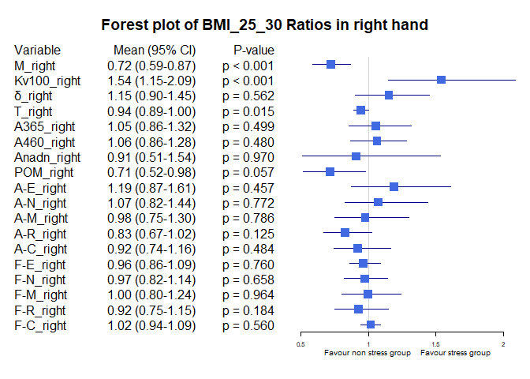

Bảng BMI ratio, level1 = “BMI >=30”, level2 = “BMI [25-30)”

|  | Variable | Subgroup | Level1_Mean | Level2_Mean | Ratio | CI_Lower | CI_Upper | P_Value |
| --- | --- | --- | --- | --- | --- | --- | --- | --- |
| M_right | M_right | BMI_25_30 | 27.9056667 | 26.0839103 | 1.0698422 | 0.9288056 | 1.245467 | 0.8464371 |
| Kv100_right | Kv100_right | BMI_25_30 | 16.5782619 | 15.6113462 | 1.0619367 | 0.6857803 | 1.603066 | 0.4495188 |
| δ_right | δ_right | BMI_25_30 | 4.2837381 | 3.3787821 | 1.2678350 | 0.9212020 | 1.685212 | 0.2094233 |
| T_right | T_right | BMI_25_30 | 33.8068810 | 32.1312179 | 1.0521506 | 0.9958539 | 1.113402 | 0.2147228 |
| A365_right | A365_right | BMI_25_30 | 95.7547619 | 79.8782051 | 1.1987596 | 0.9398536 | 1.503023 | 0.2521084 |
| A460_right | A460_right | BMI_25_30 | 50.1476190 | 48.1025641 | 1.0425145 | 0.8950196 | 1.229767 | 0.8085450 |
| Anadn_right | Anadn_right | BMI_25_30 | 0.6214286 | 0.8897436 | 0.6984356 | 0.3921170 | 1.234581 | 0.2518704 |
| POM_right | POM_right | BMI_25_30 | 11.1420714 | 11.1483333 | 0.9994383 | 0.7078514 | 1.352949 | 0.5603355 |
| A-E_right | A-E_right | BMI_25_30 | 1.7250952 | 1.1963462 | 1.4419700 | 0.9662997 | 2.057927 | 0.1196845 |
| A-N_right | A-N_right | BMI_25_30 | 1.6431429 | 1.2500000 | 1.3145143 | 0.8661384 | 1.817629 | 0.1400177 |
| A-M_right | A-M_right | BMI_25_30 | 1.0784524 | 1.0910897 | 0.9884177 | 0.6940596 | 1.348573 | 0.7143005 |
| A-R_right | A-R_right | BMI_25_30 | 0.6946190 | 0.7613462 | 0.9123564 | 0.7358141 | 1.134896 | 0.8428508 |
| A-C_right | A-C_right | BMI_25_30 | 0.9502381 | 0.9360897 | 1.0151143 | 0.7591429 | 1.371095 | 0.7411499 |
| F-E_right | F-E_right | BMI_25_30 | 0.0162810 | 0.0149295 | 1.0905232 | 0.9289165 | 1.266388 | 0.5646466 |
| F-N_right | F-N_right | BMI_25_30 | 0.0312857 | 0.0333269 | 0.9387520 | 0.7431795 | 1.187689 | 0.7574739 |
| F-M_right | F-M_right | BMI_25_30 | 0.0758143 | 0.0875962 | 0.8654979 | 0.6709129 | 1.114196 | 0.6567835 |
| F-R_right | F-R_right | BMI_25_30 | 0.3879738 | 0.3303718 | 1.1743551 | 0.9172456 | 1.493646 | 0.1065058 |
| F-C_right | F-C_right | BMI_25_30 | 1.1907714 | 1.1260833 | 1.0574452 | 0.9347474 | 1.188536 | 0.3313442 |

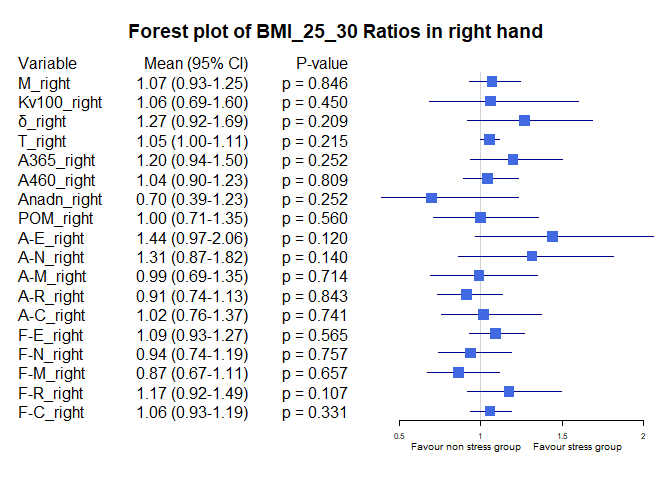

Bảng Age_stage ratio, level1 = “Age <30”, level2= “Age [30-40)”

|  | Variable | Subgroup | Level1_Mean | Level2_Mean | Ratio | CI_Lower | CI_Upper | P_Value |
| --- | --- | --- | --- | --- | --- | --- | --- | --- |
| M_right | M_right | Age_stage | 19.1767949 | 25.1828778 | 0.7615013 | 0.5954919 | 0.9284725 | 0.0471639 |
| Kv100_right | Kv100_right | Age_stage | 23.4133974 | 18.5590389 | 1.2615630 | 0.9590258 | 1.6560902 | 0.1059833 |
| δ_right | δ_right | Age_stage | 3.5846795 | 4.1187056 | 0.8703413 | 0.6582994 | 1.1162316 | 0.3242252 |
| T_right | T_right | Age_stage | 30.5505769 | 32.0664944 | 0.9527258 | 0.8970604 | 1.0066953 | 0.1423890 |
| A365_right | A365_right | Age_stage | 80.2179487 | 88.3650000 | 0.9078023 | 0.6961894 | 1.1241183 | 0.8180587 |
| A460_right | A460_right | Age_stage | 46.0897436 | 51.6011111 | 0.8931929 | 0.7143378 | 1.0875961 | 0.4399218 |
| Anadn_right | Anadn_right | Age_stage | 0.8906410 | 0.6636667 | 1.3420005 | 0.8945844 | 1.9951527 | 0.9672279 |
| POM_right | POM_right | Age_stage | 8.4367308 | 10.7492056 | 0.7848702 | 0.5272991 | 1.1371936 | 0.0369747 |
| A-E_right | A-E_right | Age_stage | 1.2639744 | 1.5125222 | 0.8356732 | 0.5996076 | 1.1395647 | 0.1482239 |
| A-N_right | A-N_right | Age_stage | 1.2549359 | 1.3908444 | 0.9022834 | 0.6798270 | 1.1889492 | 0.5990254 |
| A-M_right | A-M_right | Age_stage | 1.0476923 | 1.0886944 | 0.9623383 | 0.7228149 | 1.2760827 | 0.7549002 |
| A-R_right | A-R_right | Age_stage | 0.6694231 | 0.6721333 | 0.9959677 | 0.7754660 | 1.2602541 | 0.7115788 |
| A-C_right | A-C_right | Age_stage | 0.8508333 | 0.9003333 | 0.9450204 | 0.7610433 | 1.1897650 | 0.2929065 |
| F-E_right | F-E_right | Age_stage | 0.0143013 | 0.0147044 | 0.9725823 | 0.8608896 | 1.1088395 | 0.6259169 |
| F-N_right | F-N_right | Age_stage | 0.0371603 | 0.0307389 | 1.2089004 | 1.0375146 | 1.4065480 | 0.0202081 |
| F-M_right | F-M_right | Age_stage | 0.0896731 | 0.0839844 | 1.0677344 | 0.8550541 | 1.3326478 | 0.7339582 |
| F-R_right | F-R_right | Age_stage | 0.2993397 | 0.3425494 | 0.8738585 | 0.6970253 | 1.1141749 | 0.1365375 |
| F-C_right | F-C_right | Age_stage | 1.1121731 | 1.1828467 | 0.9402513 | 0.8568789 | 1.0281727 | 0.3434453 |

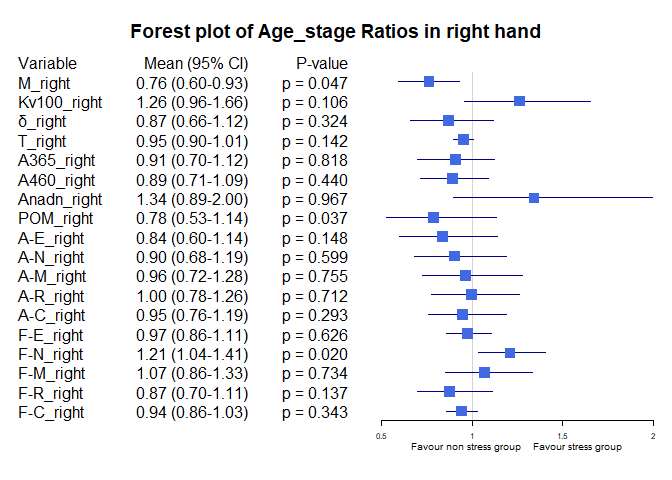

Bảng Age_stage ratio, level1 = “Age <30”, level2= “Age [40-50)”

|  | Variable | Subgroup | Level1_Mean | Level2_Mean | Ratio | CI_Lower | CI_Upper | P_Value |
| --- | --- | --- | --- | --- | --- | --- | --- | --- |
| M_right | M_right | Age_stage | 19.1767949 | 22.9460769 | 0.8357331 | 0.6147226 | 1.205393 | 0.2428218 |
| Kv100_right | Kv100_right | Age_stage | 23.4133974 | 13.9024615 | 1.6841188 | 1.2399653 | 2.350868 | 0.0114719 |
| δ_right | δ_right | Age_stage | 3.5846795 | 2.9100769 | 1.2318161 | 0.8463595 | 1.944724 | 0.2834385 |
| T_right | T_right | Age_stage | 30.5505769 | 31.4998462 | 0.9698643 | 0.8919245 | 1.077294 | 0.2678025 |
| A365_right | A365_right | Age_stage | 80.2179487 | 79.0384615 | 1.0149230 | 0.7248475 | 1.490481 | 0.7317482 |
| A460_right | A460_right | Age_stage | 46.0897436 | 54.7230769 | 0.8422360 | 0.6291193 | 1.176283 | 0.2969528 |
| Anadn_right | Anadn_right | Age_stage | 0.8906410 | 1.1620769 | 0.7664217 | 0.3681286 | 1.607992 | 0.1108180 |
| POM_right | POM_right | Age_stage | 8.4367308 | 7.4463077 | 1.1330086 | 0.6927124 | 1.894214 | 0.7800367 |
| A-E_right | A-E_right | Age_stage | 1.2639744 | 1.2010000 | 1.0524349 | 0.6804216 | 1.696495 | 0.6124748 |
| A-N_right | A-N_right | Age_stage | 1.2549359 | 1.3010000 | 0.9645933 | 0.6450435 | 1.626202 | 0.7771352 |
| A-M_right | A-M_right | Age_stage | 1.0476923 | 1.0203846 | 1.0267622 | 0.6879526 | 1.710442 | 0.6441561 |
| A-R_right | A-R_right | Age_stage | 0.6694231 | 0.6776923 | 0.9877980 | 0.7060619 | 1.437978 | 0.8815488 |
| A-C_right | A-C_right | Age_stage | 0.8508333 | 0.8823846 | 0.9642432 | 0.6600238 | 1.534716 | 1.0000000 |
| F-E_right | F-E_right | Age_stage | 0.0143013 | 0.0146231 | 0.9779940 | 0.8367962 | 1.153158 | 0.7407631 |
| F-N_right | F-N_right | Age_stage | 0.0371603 | 0.0274385 | 1.3543127 | 1.1419179 | 1.593509 | 0.0055101 |
| F-M_right | F-M_right | Age_stage | 0.0896731 | 0.0822846 | 1.0897915 | 0.8171026 | 1.421576 | 0.8804623 |
| F-R_right | F-R_right | Age_stage | 0.2993397 | 0.2911077 | 1.0282784 | 0.7866755 | 1.373089 | 0.9148398 |
| F-C_right | F-C_right | Age_stage | 1.1121731 | 1.1499538 | 0.9671458 | 0.8601369 | 1.080689 | 0.8577822 |

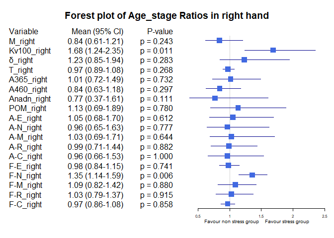

Bảng Age_stage ratio, level1 = “Age <30”, level2= “Age >=50”

|  | Variable | Subgroup | Level1_Mean | Level2_Mean | Ratio | CI_Lower | CI_Upper | P_Value |
| --- | --- | --- | --- | --- | --- | --- | --- | --- |
| M_right | M_right | Age_stage | 19.1767949 | 18.7191667 | 1.0244470 | 0.6406862 | 1.998826 | 0.8323953 |
| Kv100_right | Kv100_right | Age_stage | 23.4133974 | 31.1008333 | 0.7528222 | 0.5035111 | 1.364393 | 0.3312874 |
| δ_right | δ_right | Age_stage | 3.5846795 | 4.4163889 | 0.8116766 | 0.5519612 | 1.368115 | 0.3464204 |
| T_right | T_right | Age_stage | 30.5505769 | 29.6863889 | 1.0291106 | 0.9029171 | 1.184259 | 0.6292031 |
| A365_right | A365_right | Age_stage | 80.2179487 | 85.8611111 | 0.9342757 | 0.6911474 | 1.213611 | 0.9614821 |
| A460_right | A460_right | Age_stage | 46.0897436 | 48.4444444 | 0.9513938 | 0.6437240 | 1.511940 | 0.9807355 |
| Anadn_right | Anadn_right | Age_stage | 0.8906410 | 0.5352778 | 1.6638857 | 1.0529945 | 2.671831 | 0.4834445 |
| POM_right | POM_right | Age_stage | 8.4367308 | 10.5338889 | 0.8009132 | 0.4143015 | 1.988424 | 0.7958821 |
| A-E_right | A-E_right | Age_stage | 1.2639744 | 1.5108333 | 0.8366074 | 0.5301176 | 1.524850 | 0.4116500 |
| A-N_right | A-N_right | Age_stage | 1.2549359 | 1.5183333 | 0.8265220 | 0.5585374 | 1.356202 | 0.5144235 |
| A-M_right | A-M_right | Age_stage | 1.0476923 | 1.2411111 | 0.8441567 | 0.6039840 | 1.311464 | 0.4837655 |
| A-R_right | A-R_right | Age_stage | 0.6694231 | 0.7813889 | 0.8567092 | 0.6668928 | 1.125636 | 0.2179285 |
| A-C_right | A-C_right | Age_stage | 0.8508333 | 1.0866667 | 0.7829755 | 0.5021518 | 1.209633 | 0.3104137 |
| F-E_right | F-E_right | Age_stage | 0.0143013 | 0.0170556 | 0.8385117 | 0.7186638 | 1.004850 | 0.1581949 |
| F-N_right | F-N_right | Age_stage | 0.0371603 | 0.0337500 | 1.1010446 | 0.8237643 | 1.461098 | 0.2764155 |
| F-M_right | F-M_right | Age_stage | 0.0896731 | 0.0928611 | 0.9656688 | 0.6475517 | 1.480285 | 1.0000000 |
| F-R_right | F-R_right | Age_stage | 0.2993397 | 0.3820556 | 0.7834979 | 0.5891013 | 1.061166 | 0.0949007 |
| F-C_right | F-C_right | Age_stage | 1.1121731 | 1.0606111 | 1.0486153 | 0.9277673 | 1.198416 | 0.4973082 |

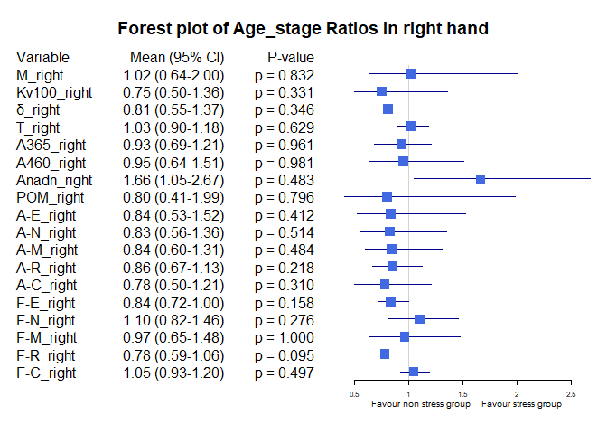

Bảng Age_stage ratio, level1 = “Age [30-40)”, level2= “Age >=50”

|  | Variable | Subgroup | Level1_Mean | Level2_Mean | Ratio | CI_Lower | CI_Upper | P_Value |
| --- | --- | --- | --- | --- | --- | --- | --- | --- |
| M_right | M_right | Age_stage | 25.1828778 | 18.7191667 | 1.3452991 | 0.8846970 | 2.471357 | 0.3068264 |
| Kv100_right | Kv100_right | Age_stage | 18.5590389 | 31.1008333 | 0.5967377 | 0.3981042 | 1.072827 | 0.0778923 |
| δ_right | δ_right | Age_stage | 4.1187056 | 4.4163889 | 0.9325958 | 0.6506286 | 1.479862 | 0.8200619 |
| T_right | T_right | Age_stage | 32.0664944 | 29.6863889 | 1.0801750 | 0.9590505 | 1.246726 | 0.4176041 |
| A365_right | A365_right | Age_stage | 88.3650000 | 85.8611111 | 1.0291621 | 0.8525691 | 1.268052 | 0.6866670 |
| A460_right | A460_right | Age_stage | 51.6011111 | 48.4444444 | 1.0651606 | 0.7769065 | 1.677647 | 0.7340403 |
| Anadn_right | Anadn_right | Age_stage | 0.6636667 | 0.5352778 | 1.2398547 | 0.9475872 | 1.687527 | 0.3840815 |
| POM_right | POM_right | Age_stage | 10.7492056 | 10.5338889 | 1.0204404 | 0.5607696 | 2.427508 | 0.6045327 |
| A-E_right | A-E_right | Age_stage | 1.5125222 | 1.5108333 | 1.0011179 | 0.6702397 | 1.781249 | 0.8651577 |
| A-N_right | A-N_right | Age_stage | 1.3908444 | 1.5183333 | 0.9160337 | 0.6316781 | 1.604182 | 0.4575245 |
| A-M_right | A-M_right | Age_stage | 1.0886944 | 1.2411111 | 0.8771934 | 0.6135678 | 1.329767 | 0.3841733 |
| A-R_right | A-R_right | Age_stage | 0.6721333 | 0.7813889 | 0.8601777 | 0.6808147 | 1.114223 | 0.2981686 |
| A-C_right | A-C_right | Age_stage | 0.9003333 | 1.0866667 | 0.8285276 | 0.5943185 | 1.272392 | 0.4321405 |
| F-E_right | F-E_right | Age_stage | 0.0147044 | 0.0170556 | 0.8621498 | 0.7514868 | 1.020754 | 0.1304696 |
| F-N_right | F-N_right | Age_stage | 0.0307389 | 0.0337500 | 0.9107819 | 0.6812239 | 1.177808 | 0.3594228 |
| F-M_right | F-M_right | Age_stage | 0.0839844 | 0.0928611 | 0.9044092 | 0.5906014 | 1.339277 | 0.7647571 |
| F-R_right | F-R_right | Age_stage | 0.3425494 | 0.3820556 | 0.8965959 | 0.6969650 | 1.181379 | 0.4415227 |
| F-C_right | F-C_right | Age_stage | 1.1828467 | 1.0606111 | 1.1152501 | 0.9887841 | 1.258023 | 0.0883704 |

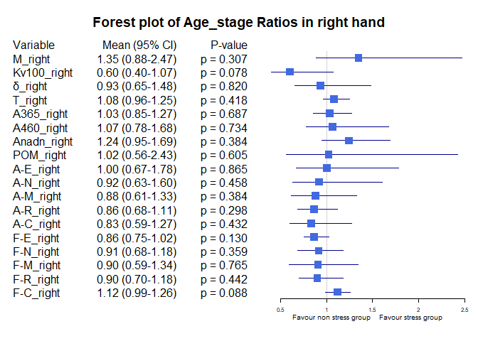

Bảng Age_stage ratio, level1 = “Age [30-40)”, level2= “Age [40-50)”

|  | Variable | Subgroup | Level1_Mean | Level2_Mean | Ratio | CI_Lower | CI_Upper | P_Value |
| --- | --- | --- | --- | --- | --- | --- | --- | --- |
| M_right | M_right | Age_stage | 25.1828778 | 22.9460769 | 1.0974808 | 0.8755265 | 1.497364 | 1.0000000 |
| Kv100_right | Kv100_right | Age_stage | 18.5590389 | 13.9024615 | 1.3349462 | 0.9529168 | 1.902529 | 0.2024166 |
| δ_right | δ_right | Age_stage | 4.1187056 | 2.9100769 | 1.4153253 | 0.9713543 | 2.226987 | 0.0882063 |
| T_right | T_right | Age_stage | 32.0664944 | 31.4998462 | 1.0179889 | 0.9392447 | 1.116080 | 0.6289108 |
| A365_right | A365_right | Age_stage | 88.3650000 | 79.0384615 | 1.1180000 | 0.8724287 | 1.578543 | 0.6720993 |
| A460_right | A460_right | Age_stage | 51.6011111 | 54.7230769 | 0.9429497 | 0.7528894 | 1.244479 | 0.3683792 |
| Anadn_right | Anadn_right | Age_stage | 0.6636667 | 1.1620769 | 0.5711039 | 0.3062740 | 1.054704 | 0.1248584 |
| POM_right | POM_right | Age_stage | 10.7492056 | 7.4463077 | 1.4435618 | 1.0025895 | 2.298305 | 0.0544468 |
| A-E_right | A-E_right | Age_stage | 1.5125222 | 1.2010000 | 1.2593857 | 0.8553248 | 2.117437 | 0.2042906 |
| A-N_right | A-N_right | Age_stage | 1.3908444 | 1.3010000 | 1.0690580 | 0.7043877 | 1.791095 | 0.5968292 |
| A-M_right | A-M_right | Age_stage | 1.0886944 | 1.0203846 | 1.0669452 | 0.7226204 | 1.780579 | 0.5696308 |
| A-R_right | A-R_right | Age_stage | 0.6721333 | 0.6776923 | 0.9917972 | 0.7344678 | 1.423215 | 0.9578000 |
| A-C_right | A-C_right | Age_stage | 0.9003333 | 0.8823846 | 1.0203412 | 0.7305771 | 1.497974 | 0.5429053 |
| F-E_right | F-E_right | Age_stage | 0.0147044 | 0.0146231 | 1.0055643 | 0.8665320 | 1.162121 | 0.8728857 |
| F-N_right | F-N_right | Age_stage | 0.0307389 | 0.0274385 | 1.1202847 | 0.9318933 | 1.340640 | 0.4887332 |
| F-M_right | F-M_right | Age_stage | 0.0839844 | 0.0822846 | 1.0206579 | 0.7634732 | 1.304324 | 0.8730113 |
| F-R_right | F-R_right | Age_stage | 0.3425494 | 0.2911077 | 1.1767104 | 0.9204812 | 1.550814 | 0.2135983 |
| F-C_right | F-C_right | Age_stage | 1.1828467 | 1.1499538 | 1.0286036 | 0.9441087 | 1.124699 | 0.2930937 |

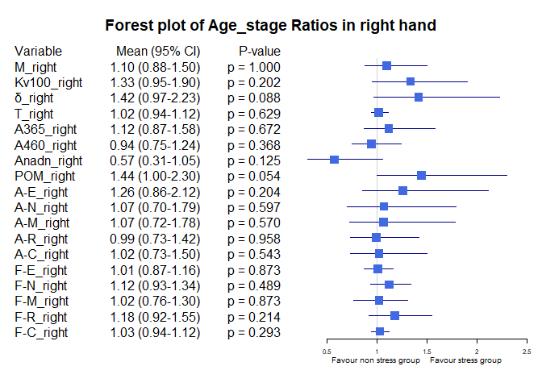

Bảng Age_stage ratio, level1 = “Age [40-50)”, level2= “Age >=50”

|  | Variable | Subgroup | Level1_Mean | Level2_Mean | Ratio | CI_Lower | CI_Upper | P_Value |
| --- | --- | --- | --- | --- | --- | --- | --- | --- |
| M_right | M_right | Age_stage | 22.9460769 | 18.7191667 | 1.2258065 | 0.7486838 | 2.4186278 | 0.8982751 |
| Kv100_right | Kv100_right | Age_stage | 13.9024615 | 31.1008333 | 0.4470125 | 0.2820286 | 0.7958902 | 0.0364883 |
| δ_right | δ_right | Age_stage | 2.9100769 | 4.4163889 | 0.6589268 | 0.3990227 | 1.1268990 | 0.1791243 |
| T_right | T_right | Age_stage | 31.4998462 | 29.6863889 | 1.0610872 | 0.9181371 | 1.2310712 | 0.7012384 |
| A365_right | A365_right | Age_stage | 79.0384615 | 85.8611111 | 0.9205385 | 0.6315569 | 1.2371327 | 0.9650063 |
| A460_right | A460_right | Age_stage | 54.7230769 | 48.4444444 | 1.1296048 | 0.7384098 | 1.8517561 | 0.4557722 |
| Anadn_right | Anadn_right | Age_stage | 1.1620769 | 0.5352778 | 2.1709792 | 1.0928691 | 4.3519326 | 0.0391224 |
| POM_right | POM_right | Age_stage | 7.4463077 | 10.5338889 | 0.7068907 | 0.3464130 | 1.6211879 | 0.7653693 |
| A-E_right | A-E_right | Age_stage | 1.2010000 | 1.5108333 | 0.7949255 | 0.4551000 | 1.5606699 | 0.4155241 |
| A-N_right | A-N_right | Age_stage | 1.3010000 | 1.5183333 | 0.8568606 | 0.4971268 | 1.5066864 | 0.6607237 |
| A-M_right | A-M_right | Age_stage | 1.0203846 | 1.2411111 | 0.8221541 | 0.4746393 | 1.3510687 | 0.4045229 |
| A-R_right | A-R_right | Age_stage | 0.6776923 | 0.7813889 | 0.8672920 | 0.6114341 | 1.2221969 | 0.7012384 |
| A-C_right | A-C_right | Age_stage | 0.8823846 | 1.0866667 | 0.8120104 | 0.4771328 | 1.3722822 | 0.3676102 |
| F-E_right | F-E_right | Age_stage | 0.0146231 | 0.0170556 | 0.8573791 | 0.7287384 | 1.0227563 | 0.2669821 |
| F-N_right | F-N_right | Age_stage | 0.0274385 | 0.0337500 | 0.8129915 | 0.6105899 | 1.0808743 | 0.2010800 |
| F-M_right | F-M_right | Age_stage | 0.0822846 | 0.0928611 | 0.8861041 | 0.5788312 | 1.3546795 | 1.0000000 |
| F-R_right | F-R_right | Age_stage | 0.2911077 | 0.3820556 | 0.7619512 | 0.5603518 | 1.0758448 | 0.1028555 |
| F-C_right | F-C_right | Age_stage | 1.1499538 | 1.0606111 | 1.0842370 | 0.9422812 | 1.2334057 | 0.2495928 |

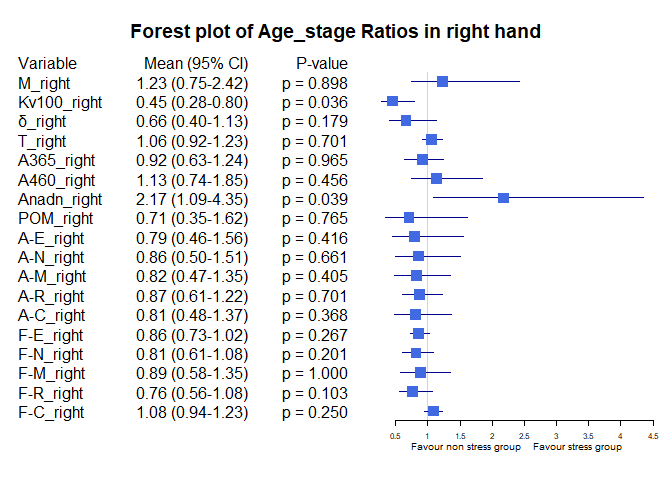